# Rushaliben Manishbhai More

## Module 1 Report - Olympic Games

# 1. Objective of the Proposed Research

The purpose of this study is to analyse individual athelete data and provide a suggestion to one of the main sponsors for the next olmpics,Kellogs, on the basis of parameters such as the game they play, the team they belong to, the city they belong to, the olympic season and year they played for and also the medals won by them so far.

On the basis of the data gathered, it would create a huge impact on the audience if the sponsor company gets the right athelete which withstands their requirements and is capable of pulling customers to their way.

Also, the age, experience, medals won, sex, the country they belong to would be one of the important aspect to chose the right athelete.

Reading the csv files

```r
csv1 <- read.csv('/content/athlete_events.csv')
csv2 <- read.csv('/content/noc_regions.csv')
```

importing libraries

```r
library(dplyr)
library(tidyverse)
library(tidyr)
```

Getting column names

```r
names(csv1)
names(csv2)
```

1. 'ID'

2. 'Name'

3. 'Sex'

4. 'Age'

5. 'Height'

6. 'Weight'

7. 'Team'

8. 'NOC'

9. 'Games'

10. 'Year'

11. 'Season'

12. 'City'

13. 'Sport'

14. 'Event'

15. 'Medal'

1. 'NOC'

2. 'region'

3. 'notes'

using glimpse() to have information about the no of rows and column, type of data and also a brief overview of data

```r
glimpse(csv1)
glimpse(csv2)
```

```
Rows: 271,116
Columns: 15
$ ID     <int> 1, 2, 3, 4, 5, 5, 5, 5, 5, 5, 6, 6, 6, 6, 6, 6, 6, 6, 7, 7, 7, …
$ Name   <chr> "A Dijiang", "A Lamusi", "Gunnar Nielsen Aaby", "Edgar Lindenau…
$ Sex    <chr> "M", "M", "M", "M", "F", "F", "F", "F", "F", "F", "M", "M", "M"…
$ Age    <int> 24, 23, 24, 34, 21, 21, 25, 25, 27, 27, 31, 31, 31, 31, 33, 33,…
$ Height <int> 180, 170, NA, NA, 185, 185, 185, 185, 185, 185, 188, 188, 188, …
$ Weight <dbl> 80, 60, NA, NA, 82, 82, 82, 82, 82, 82, 75, 75, 75, 75, 75, 75,…
$ Team   <chr> "China", "China", "Denmark", "Denmark/Sweden", "Netherlands", "…
$ NOC    <chr> "CHN", "CHN", "DEN", "DEN", "NED", "NED", "NED", "NED", "NED", …
$ Games  <chr> "1992 Summer", "2012 Summer", "1920 Summer", "1900 Summer", "19…
$ Year   <int> 1992, 2012, 1920, 1900, 1988, 1988, 1992, 1992, 1994, 1994, 199…
$ Season <chr> "Summer", "Summer", "Summer", "Summer", "Winter", "Winter", "Wi…
$ City   <chr> "Barcelona", "London", "Antwerpen", "Paris", "Calgary", "Calgar…
$ Sport  <chr> "Basketball", "Judo", "Football", "Tug-Of-War", "Speed Skating"…
$ Event  <chr> "Basketball Men's Basketball", "Judo Men's Extra-Lightweight", …
$ Medal  <chr> NA, NA, NA, "Gold", NA, NA, NA, NA, NA, NA, NA, NA, NA, NA, NA,…
Rows: 230
Columns: 3
$ NOC    <chr> "AFG", "AHO", "ALB", "ALG", "AND", "ANG", "ANT", "ANZ", "ARG", …
$ region <chr> "Afghanistan", "Curacao", "Albania", "Algeria", "Andorra", "Ang…
$ notes  <chr> "", "Netherlands Antilles", "", "", "", "", "Antigua and Barbud…
```

using merge() to have an inner join on both the csv

```r
main.dataframe <- merge(x=csv1,y=csv2, by="NOC")
```

# 2. Data Exploration

using head() to display the first 10 rows of data

```r
head(main.dataframe,10)
```

A data.frame: 10 × 17

|  | NOC <chr> | ID <int> | Name <chr> | Sex <chr> | Age <int> | Height <int> | Weight <dbl> | Team <chr> | Games <chr> | Year <int> | Season <chr> | City <chr> | Sport <chr> | Event <chr> | Medal <chr> | region <chr> | notes <chr> |
| --- | --- | --- | --- | --- | --- | --- | --- | --- | --- | --- | --- | --- | --- | --- | --- | --- | --- |
| 1 | AFG | 132181 | Najam Yahya | M | NA | NA | NA | Afghanistan | 1956 Summer | 1956 | Summer | Melbourne | Hockey | Hockey Men's Hockey | NA | Afghanistan |  |
| 2 | AFG | 87371 | Ahmad Jahan Nuristani | M | NA | NA | NA | Afghanistan | 1948 Summer | 1948 | Summer | London | Hockey | Hockey Men's Hockey | NA | Afghanistan |  |
| 3 | AFG | 44977 | Mohammad Halilula | M | 28 | 163 | 57 | Afghanistan | 1980 Summer | 1980 | Summer | Moskva | Wrestling | Wrestling Men's Bantamweight, Freestyle | NA | Afghanistan |  |
| 4 | AFG | 502 | Ahmad Shah Abouwi | M | NA | NA | NA | Afghanistan | 1956 Summer | 1956 | Summer | Melbourne | Hockey | Hockey Men's Hockey | NA | Afghanistan |  |
| 5 | AFG | 109153 | Shakar Khan Shakar | M | 24 | NA | 74 | Afghanistan | 1964 Summer | 1964 | Summer | Tokyo | Wrestling | Wrestling Men's Welterweight, Freestyle | NA | Afghanistan |  |
| 6 | AFG | 29626 | Sultan Mohammad Dost | M | 28 | 168 | 73 | Afghanistan | 1960 Summer | 1960 | Summer | Roma | Wrestling | Wrestling Men's Welterweight, Freestyle | NA | Afghanistan |  |
| 7 | AFG | 1076 | Jammal-ud-Din Affendi | M | 28 | NA | NA | Afghanistan | 1936 Summer | 1936 | Summer | Berlin | Hockey | Hockey Men's Hockey | NA | Afghanistan |  |
| 8 | AFG | 121376 | Khan Nasrullah Totakhail | M | NA | NA | NA | Afghanistan | 1956 Summer | 1956 | Summer | Melbourne | Hockey | Hockey Men's Hockey | NA | Afghanistan |  |
| 9 | AFG | 80210 | Alam Mir | M | NA | NA | 57 | Afghanistan | 1972 Summer | 1972 | Summer | Munich | Wrestling | Wrestling Men's Bantamweight, Greco-Roman | NA | Afghanistan |  |
| 10 | AFG | 87374 | Mohammad Amin Nuristani | M | NA | NA | NA | Afghanistan | 1956 Summer | 1956 | Summer | Melbourne | Hockey | Hockey Men's Hockey | NA | Afghanistan |  |

handling missing data : replacing null values in numerical columns using mean of that column

```r
main.dataframe$Height[is.na(main.dataframe$Height)]<-mean(main.dataframe$Height,na.rm=T)
main.dataframe$Weight[is.na(main.dataframe$Weight)]<-mean(main.dataframe$Weight,na.rm=T)
main.dataframe$Age[is.na(main.dataframe$Age)]<-mean(main.dataframe$Age,na.rm=T)
```

handling missing data : replacing the null values with a string

```r
main.dataframe$Medal = main.dataframe$Medal %>% replace_na('No Medal')
```

using head() to check the values being replaced well

```r
head(main.dataframe,10)
```

A data.frame: 10 × 17

|  | NOC <chr> | ID <int> | Name <chr> | Sex <chr> | Age <dbl> | Height <dbl> | Weight <dbl> | Team <chr> | Games <chr> | Year <int> | Season <chr> | City <chr> | Sport <chr> | Event <chr> | Medal <chr> | region <chr> | notes <chr> |
| --- | --- | --- | --- | --- | --- | --- | --- | --- | --- | --- | --- | --- | --- | --- | --- | --- | --- |
| 1 | AFG | 132181 | Najam Yahya | M | 25.55978 | 175.3443 | 70.70952 | Afghanistan | 1956 Summer | 1956 | Summer | Melbourne | Hockey | Hockey Men's Hockey | No Medal | Afghanistan |  |
| 2 | AFG | 87371 | Ahmad Jahan Nuristani | M | 25.55978 | 175.3443 | 70.70952 | Afghanistan | 1948 Summer | 1948 | Summer | London | Hockey | Hockey Men's Hockey | No Medal | Afghanistan |  |
| 3 | AFG | 44977 | Mohammad Halilula | M | 28.00000 | 163.0000 | 57.00000 | Afghanistan | 1980 Summer | 1980 | Summer | Moskva | Wrestling | Wrestling Men's Bantamweight, Freestyle | No Medal | Afghanistan |  |
| 4 | AFG | 502 | Ahmad Shah Abouwi | M | 25.55978 | 175.3443 | 70.70952 | Afghanistan | 1956 Summer | 1956 | Summer | Melbourne | Hockey | Hockey Men's Hockey | No Medal | Afghanistan |  |
| 5 | AFG | 109153 | Shakar Khan Shakar | M | 24.00000 | 175.3443 | 74.00000 | Afghanistan | 1964 Summer | 1964 | Summer | Tokyo | Wrestling | Wrestling Men's Welterweight, Freestyle | No Medal | Afghanistan |  |
| 6 | AFG | 29626 | Sultan Mohammad Dost | M | 28.00000 | 168.0000 | 73.00000 | Afghanistan | 1960 Summer | 1960 | Summer | Roma | Wrestling | Wrestling Men's Welterweight, Freestyle | No Medal | Afghanistan |  |
| 7 | AFG | 1076 | Jammal-ud-Din Affendi | M | 28.00000 | 175.3443 | 70.70952 | Afghanistan | 1936 Summer | 1936 | Summer | Berlin | Hockey | Hockey Men's Hockey | No Medal | Afghanistan |  |
| 8 | AFG | 121376 | Khan Nasrullah Totakhail | M | 25.55978 | 175.3443 | 70.70952 | Afghanistan | 1956 Summer | 1956 | Summer | Melbourne | Hockey | Hockey Men's Hockey | No Medal | Afghanistan |  |
| 9 | AFG | 80210 | Alam Mir | M | 25.55978 | 175.3443 | 57.00000 | Afghanistan | 1972 Summer | 1972 | Summer | Munich | Wrestling | Wrestling Men's Bantamweight, Greco-Roman | No Medal | Afghanistan |  |
| 10 | AFG | 87374 | Mohammad Amin Nuristani | M | 25.55978 | 175.3443 | 70.70952 | Afghanistan | 1956 Summer | 1956 | Summer | Melbourne | Hockey | Hockey Men's Hockey | No Medal | Afghanistan |  |

using dim() to get number of rows and columns

```r
dim(main.dataframe)
```

1. 270767

2. 17

using summary() to get a summarize view of the data

```r
summary(main.dataframe)
```

```
     NOC                  ID             Name               Sex
 Length:270767      Min.   :     1   Length:270767      Length:270767
 Class :character   1st Qu.: 34630   Class :character   Class :character
 Mode  :character   Median : 68187   Mode  :character   Mode  :character
                    Mean   : 68229
                    3rd Qu.:102066
                    Max.   :135571
      Age            Height          Weight           Team
 Min.   :10.00   Min.   :127.0   Min.   : 25.00   Length:270767
 1st Qu.:22.00   1st Qu.:170.0   1st Qu.: 63.00   Class :character
 Median :25.00   Median :175.3   Median : 70.71   Mode  :character
 Mean   :25.56   Mean   :175.3   Mean   : 70.71
 3rd Qu.:28.00   3rd Qu.:180.0   3rd Qu.: 75.00
 Max.   :97.00   Max.   :226.0   Max.   :214.00
    Games                Year         Season              City
 Length:270767      Min.   :1896   Length:270767      Length:270767
 Class :character   1st Qu.:1960   Class :character   Class :character
 Mode  :character   Median :1988   Mode  :character   Mode  :character
                    Mean   :1978
                    3rd Qu.:2002
                    Max.   :2016
    Sport              Event              Medal              region
 Length:270767      Length:270767      Length:270767      Length:270767
 Class :character   Class :character   Class :character   Class :character
 Mode  :character   Mode  :character   Mode  :character   Mode  :character



    notes
 Length:270767
 Class :character
 Mode  :character
```

using quantile() t get a percentiles value of the numerical columns

```r
quantile(main.dataframe$Year)
quantile(main.dataframe$Height)
quantile(main.dataframe$Weight)
quantile(main.dataframe$Age)
```

**0%**

1896

**25%**

1960

**50%**

1988

**75%**

2002

**100%**

2016

**0%**

127

**25%**

170

**50%**

175.344250156633

**75%**

180

**100%**

226

**0%**

25

**25%**

63

**50%**

70.7095229394852

**75%**

75

**100%**

214

**0%**

10

**25%**

22

**50%**

25

**75%**

28

**100%**

97

# 3. One Column Selection

using column 'Height' and 'Weight' and priting records for 10 largest value in it using arrange().

```r
main.dataframe %>% arrange(desc(Height)) %>% slice(1:10)
main.dataframe %>% arrange(desc(Weight)) %>% slice(1:10)
```

A data.frame: 10 × 17

| NOC <chr> | ID <int> | Name <chr> | Sex <chr> | Age <dbl> | Height <dbl> | Weight <dbl> | Team <chr> | Games <chr> | Year <int> | Season <chr> | City <chr> | Sport <chr> | Event <chr> | Medal <chr> | region <chr> | notes <chr> |
| --- | --- | --- | --- | --- | --- | --- | --- | --- | --- | --- | --- | --- | --- | --- | --- | --- |
| CHN | 132627 | Yao Ming | M | 20 | 226 | 141 | China | 2000 Summer | 2000 | Summer | Sydney | Basketball | Basketball Men's Basketball | No Medal | China |  |
| CHN | 132627 | Yao Ming | M | 23 | 226 | 141 | China | 2004 Summer | 2004 | Summer | Athina | Basketball | Basketball Men's Basketball | No Medal | China |  |
| CHN | 132627 | Yao Ming | M | 27 | 226 | 141 | China | 2008 Summer | 2008 | Summer | Beijing | Basketball | Basketball Men's Basketball | No Medal | China |  |
| LTU | 104059 | Arvydas Romas Sabonis | M | 27 | 223 | 122 | Lithuania | 1992 Summer | 1992 | Summer | Barcelona | Basketball | Basketball Men's Basketball | Bronze | Lithuania |  |
| LTU | 104059 | Arvydas Romas Sabonis | M | 31 | 223 | 122 | Lithuania | 1996 Summer | 1996 | Summer | Atlanta | Basketball | Basketball Men's Basketball | Bronze | Lithuania |  |
| URS | 104059 | Arvydas Romas Sabonis | M | 23 | 223 | 122 | Soviet Union | 1988 Summer | 1988 | Summer | Seoul | Basketball | Basketball Men's Basketball | Gold | Russia |  |
| USA | 16639 | Tommy Loren Burleson | M | 20 | 223 | 102 | United States | 1972 Summer | 1972 | Summer | Munich | Basketball | Basketball Men's Basketball | Silver | USA |  |
| CHN | 134621 | Zhang Zhaoxu | M | 24 | 221 | 110 | China | 2012 Summer | 2012 | Summer | London | Basketball | Basketball Men's Basketball | No Medal | China |  |
| ESP | 30409 | Roberto Dueas Hernndez | M | 24 | 221 | 137 | Spain | 2000 Summer | 2000 | Summer | Sydney | Basketball | Basketball Men's Basketball | No Medal | Spain |  |
| ESP | 30409 | Roberto Dueas Hernndez | M | 28 | 221 | 137 | Spain | 2004 Summer | 2004 | Summer | Athina | Basketball | Basketball Men's Basketball | No Medal | Spain |  |

A data.frame: 10 × 17

| NOC <chr> | ID <int> | Name <chr> | Sex <chr> | Age <dbl> | Height <dbl> | Weight <dbl> | Team <chr> | Games <chr> | Year <int> | Season <chr> | City <chr> | Sport <chr> | Event <chr> | Medal <chr> | region <chr> | notes <chr> |
| --- | --- | --- | --- | --- | --- | --- | --- | --- | --- | --- | --- | --- | --- | --- | --- | --- |
| GUM | 12177 | Ricardo Blas, Jr. | M | 21 | 183 | 214.0 | Guam | 2008 Summer | 2008 | Summer | Beijing | Judo | Judo Men's Heavyweight | No Medal | Guam |  |
| GUM | 12177 | Ricardo Blas, Jr. | M | 25 | 183 | 214.0 | Guam | 2012 Summer | 2012 | Summer | London | Judo | Judo Men's Heavyweight | No Medal | Guam |  |
| ESP | 103159 | Aytami Ruano Vega | M | 27 | 200 | 198.0 | Spain | 2004 Summer | 2004 | Summer | Athina | Judo | Judo Men's Heavyweight | No Medal | Spain |  |
| POL | 38075 | Marek Galiski | M | 29 | 200 | 190.0 | Poland | 1980 Summer | 1980 | Summer | Moskva | Wrestling | Wrestling Men's Super-Heavyweight, Greco-Roman | No Medal | Poland |  |
| USA | 118869 | Christopher J. "Chris" Taylor | M | 22 | 196 | 182.0 | United States | 1972 Summer | 1972 | Summer | Munich | Wrestling | Wrestling Men's Super-Heavyweight, Greco-Roman | No Medal | USA |  |
| USA | 118869 | Christopher J. "Chris" Taylor | M | 22 | 196 | 182.0 | United States | 1972 Summer | 1972 | Summer | Munich | Wrestling | Wrestling Men's Super-Heavyweight, Freestyle | Bronze | USA |  |
| UKR | 103580 | Valentyn Rusliakov | M | 28 | 187 | 180.0 | Ukraine | 2000 Summer | 2000 | Summer | Sydney | Judo | Judo Men's Heavyweight | No Medal | Ukraine |  |
| VEN | 103413 | Leonel Wilfredo Ruz Carmona | M | 29 | 187 | 178.0 | Venezuela | 2004 Summer | 2004 | Summer | Athina | Judo | Judo Men's Heavyweight | No Medal | Venezuela |  |
| USA | 47755 | Marcus Jerrold "Mark" Henry | M | 21 | 190 | 176.5 | United States | 1992 Summer | 1992 | Summer | Barcelona | Weightlifting | Weightlifting Men's Super-Heavyweight | No Medal | USA |  |
| USA | 47755 | Marcus Jerrold "Mark" Henry | M | 25 | 190 | 176.5 | United States | 1996 Summer | 1996 | Summer | Atlanta | Weightlifting | Weightlifting Men's Super-Heavyweight | No Medal | USA |  |

# 5. Series

Using columns like ID, Sport, Team, Event and Age to gather insights on important value. the output shows that there were 135404 atheletes participated till now.

```r
total_people <-  matrix(c(unique(main.dataframe$ID)))
nrow(total_people)
```

135404

the output shows that there were 66 atheletes sports till now.

```r
total_sport <-  matrix(c(unique(main.dataframe$Sport)))
nrow(total_sport)
```

66

the output shows that there were 1179 teams till now.

```r
total_teams <-  matrix(c(unique(main.dataframe$Team)))
nrow(total_teams)
```

1179

the output shows that there were 765 major events occured till now.

```r
total_events <-  matrix(c(unique(main.dataframe$Event)))
nrow(total_events)
```

765

used group_by() along with year and quantile() with age to get the age of youngest and oldest athelete of each olympic.

```r
minagethatyear <- main.dataframe[1:10] %>% group_by(Year) %>%
                      summarize(Age=quantile(Age,probs=  0.00))
maxagethatyear<- main.dataframe[1:10] %>% group_by(Year) %>%
                  summarize(Age=quantile(Age,probs= 1.00))
```

printing the dataframes

```r
print(minagethatyear)
print(maxagethatyear)
```

```
# A tibble: 35 × 2
    Year   Age
   <int> <dbl>
 1  1896    10
 2  1900    13
 3  1904    14
 4  1906    13
 5  1908    14
 6  1912    13
 7  1920    13
 8  1924    11
 9  1928    11
10  1932    11
# ℹ 25 more rows
# A tibble: 35 × 2
    Year   Age
   <int> <dbl>
 1  1896    40
 2  1900    71
 3  1904    71
 4  1906    54
 5  1908    61
 6  1912    67
 7  1920    72
 8  1924    81
 9  1928    97
10  1932    96
# ℹ 25 more rows
```

# 5. Plot

defining colors

```r
colors <- c("#1f77b4","#ff7f0e", "#2ca02c", "#d62728",
            "#9467bd","#8c564b", "#e377c2", "#7f7f7f",
            "#bcbd22", "#17becf")
```

loading libraries

```r
suppressPackageStartupMessages(library(ggplot2))
# Increases font size for ggplot2
theme_set(theme_gray(base_size=18))
```

creating Grounded Bar Plot for cosidering the male/female athelete ratio in every olympic year

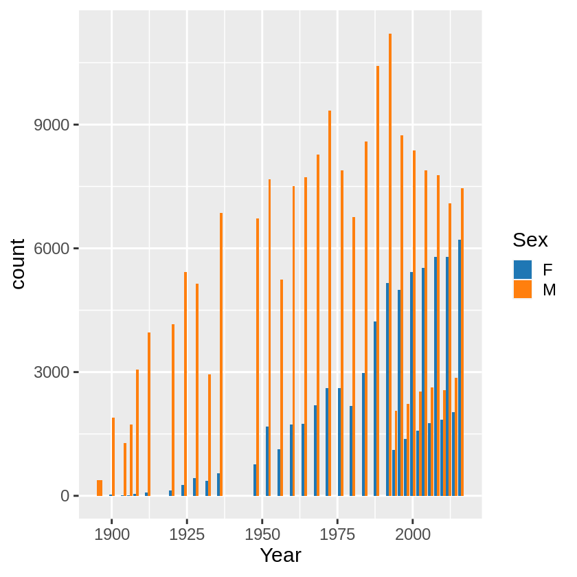

```r
main.dataframe |>
   ggplot(aes(x = Year)) +
   geom_bar(aes(fill = Sex), position = "dodge")+
   scale_fill_manual(values = colors)
```

creating a scatter plot to find any outliers if any for the BMI with Height and Weight of athelets

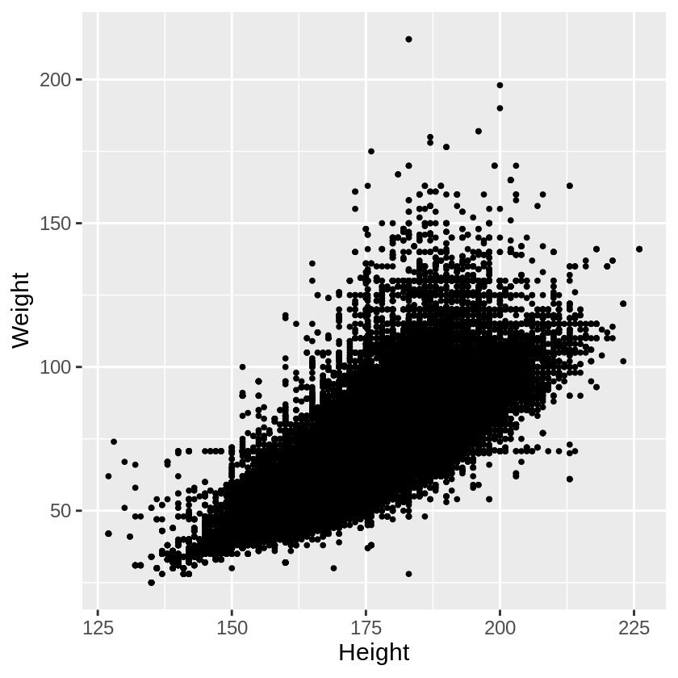

```r
main.dataframe |>
  ggplot(aes(x = Height, y = Weight)) +
  geom_point() +
  labs(x = "Height", y = "Weight")
```

# 6. Summary

For summary it would be a greater idea if the sponsor choses an athelete who has been a winner recently and also the sex of the athelete.

From the Plot above, it can be noticed that there has been a tremendous increase in the female athelete in the past few years.

Also, Majority of the atheletes have similar BMI index, and the age gap is quiet supportive to the target audience.

```r
head(main.dataframe[((main.dataframe$Medal == "Gold")&(main.dataframe$Sex == "F") & (main.dataframe$Year == 2016)),c("Name","Sex","Height","Team","Games","Sport","Event")],10)
```

A data.frame: 10 × 7

|  | Name <chr> | Sex <chr> | Height <dbl> | Team <chr> | Games <chr> | Sport <chr> | Event <chr> |
| --- | --- | --- | --- | --- | --- | --- | --- |
| 2208 | Cecilia Carranza Saroli | F | 164 | Argentina | 2016 Summer | Sailing | Sailing Mixed Multihull |
| 3917 | Paula Beln Pareto | F | 150 | Argentina | 2016 Summer | Judo | Judo Women's Extra-Lightweight |
| 5090 | Ellia Green | F | 172 | Australia | 2016 Summer | Rugby Sevens | Rugby Sevens Women's Rugby Sevens |
| 5666 | Gemma Etheridge | F | 169 | Australia | 2016 Summer | Rugby Sevens | Rugby Sevens Women's Rugby Sevens |
| 5803 | Evania Pelite | F | 169 | Australia | 2016 Summer | Rugby Sevens | Rugby Sevens Women's Rugby Sevens |
| 5866 | Emilee Cherry | F | 168 | Australia | 2016 Summer | Rugby Sevens | Rugby Sevens Women's Rugby Sevens |
| 5979 | Shannon Parry | F | 170 | Australia | 2016 Summer | Rugby Sevens | Rugby Sevens Women's Rugby Sevens |
| 6665 | Charlotte Caslick | F | 172 | Australia | 2016 Summer | Rugby Sevens | Rugby Sevens Women's Rugby Sevens |
| 6903 | Alicia Quirk | F | 173 | Australia | 2016 Summer | Rugby Sevens | Rugby Sevens Women's Rugby Sevens |
| 7235 | Sharni Williams | F | 167 | Australia | 2016 Summer | Rugby Sevens | Rugby Sevens Women's Rugby Sevens |

```r
head(main.dataframe[((main.dataframe$Medal == "Gold")&(main.dataframe$Sex == "M") & (main.dataframe$Year == 2016)),c("Name","Sex","Height","Team","Games","Sport","Event")],10)
```

A data.frame: 10 × 7

|  | Name <chr> | Sex <chr> | Height <dbl> | Team <chr> | Games <chr> | Sport <chr> | Event <chr> |
| --- | --- | --- | --- | --- | --- | --- | --- |
| 1486 | Juan Ignacio Gilardi | M | 186 | Argentina | 2016 Summer | Hockey | Hockey Men's Hockey |
| 1571 | Joaqun Menini | M | 182 | Argentina | 2016 Summer | Hockey | Hockey Men's Hockey |
| 1781 | Juan Martn Lpez | M | 178 | Argentina | 2016 Summer | Hockey | Hockey Men's Hockey |
| 2098 | Agustn Alejandro Mazzilli | M | 173 | Argentina | 2016 Summer | Hockey | Hockey Men's Hockey |
| 2365 | Juan Manuel Vivaldi | M | 180 | Argentina | 2016 Summer | Hockey | Hockey Men's Hockey |
| 2404 | Matas Enrique Paredes | M | 176 | Argentina | 2016 Summer | Hockey | Hockey Men's Hockey |
| 2511 | Ignacio Ortz | M | 180 | Argentina | 2016 Summer | Hockey | Hockey Men's Hockey |
| 2823 | Manuel Brunet | M | 179 | Argentina | 2016 Summer | Hockey | Hockey Men's Hockey |
| 2992 | Lucas Rafael Rossi | M | 188 | Argentina | 2016 Summer | Hockey | Hockey Men's Hockey |
| 3180 | Luca Masso | M | 186 | Argentina | 2016 Summer | Hockey | Hockey Men's Hockey |

# 7. Recommendations

Cecilia Carranza Saroli would be the first recommendation as she's a female athlete, gold medalist, recent olympic winner, with an amazing sport winner of SAILING.

It would promote to have more female athletes, interest in olympics and also a major interest in the rare sport of sailing.